# The Exponencial Distribution Study

DeltaSigma

## Overview

In this brief study we will try to understand the behavior of the **Exponencial Distribution**. To do that, we will perform simulations and we will compare the results with the theoretical predictions. We hope that this study will be as useful to one who reads it as it was useful to we that wrote it.

## Sample Mean versus Theoretical Mean

From theory we know that the mean and the standard deviation for the exponential distribution is given by $\frac{1}{lambda}$

We chose our *lambda* to be **0.2**. So, our theoretical mean and standard deviation are $sd = mean = \frac{1}{0.2} = 5$

So we know that the distribution is centered at **5**.

With the help of simulations we will confront the theoretical prediction with the empirical results. We will plot the mean of $n$ averages and the theoretical prediction (blue line) in a single figure to see if the averages converge to the expected value.

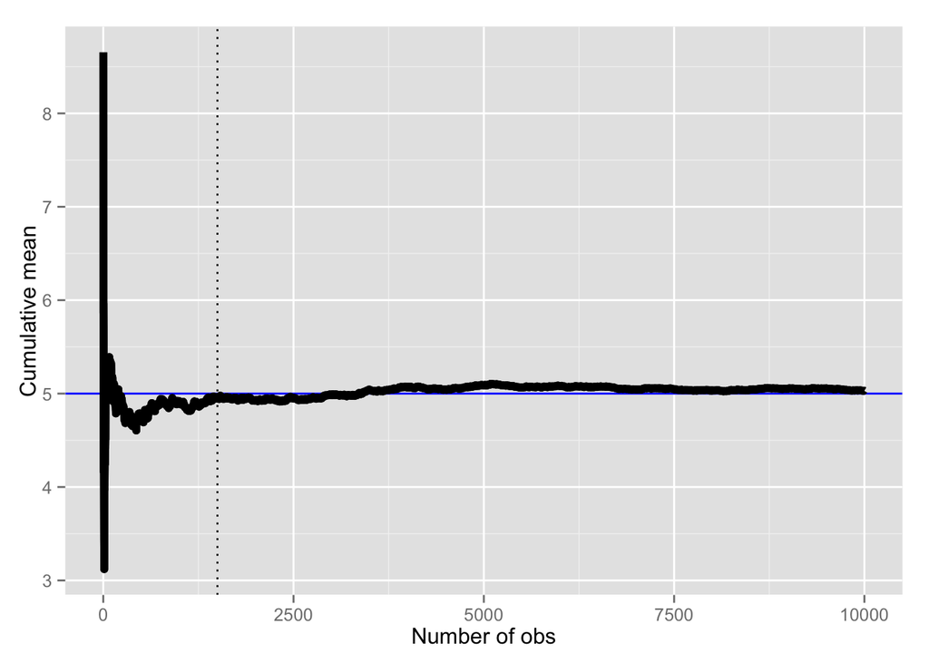

It is clear from the graphic that around $n = 1500$ (dotted line) our simulation is already very close to the theoretical value

## Sample Variance versus Theoretical Variance

The variance for a population is given by $\sigma^2$ and the variance for averages of $n$ samples is given by $\frac{\sigma^2}{n}$. We chose n to be 40 in our example.

In the previous section we discussed that the standard deviation for the exponential distribution is given by $\frac{1}{lambda}$ and we set our *lambda* to be **0.2**. So, our population variance is $\sigma^2 = (\frac{1}{0.2})^2 = 25$ and our sample variance is $\frac{\sigma^2}{n} = \frac{25}{40}=0.625$.

Now we will use simulation again to check the prediction to the empirical results. We will plot the variance of 40 averages and the theoretical sample variance prediction (blue line) in a single figure to see if the variance converge to the expected value.

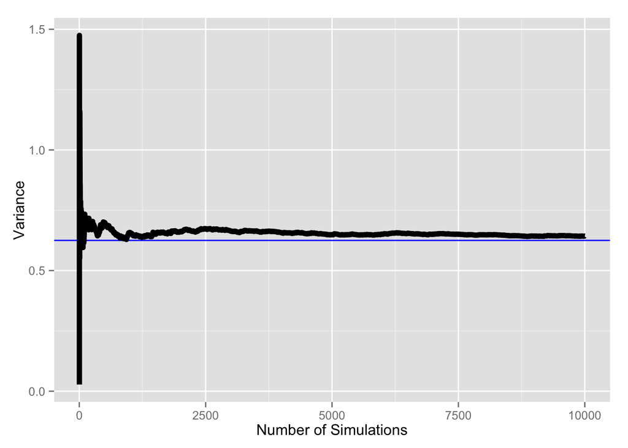

You can see that as the number of simulations increase the sample variance gets close to the theoretical value.

## Distribution

From theory we know that the sample distribution of averages is normally distributed. To see that we will plot the sample histogram.

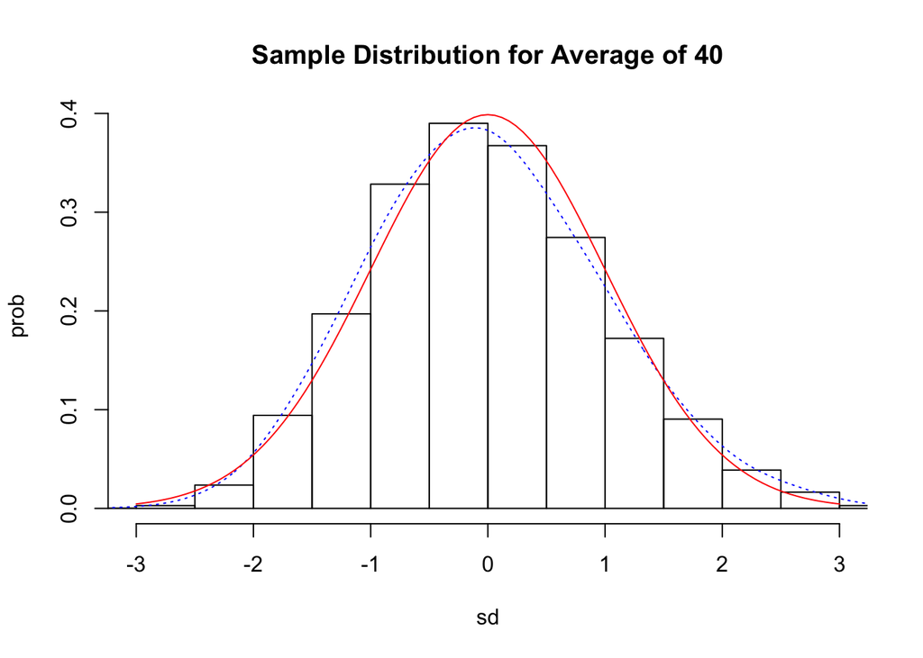

We normalized the sample by subtracting the mean and dividing by the standard deviation.

In the above graphic, the **blue** dotted line represents the probability function for this sample and the **red** line represents the normal distribution.

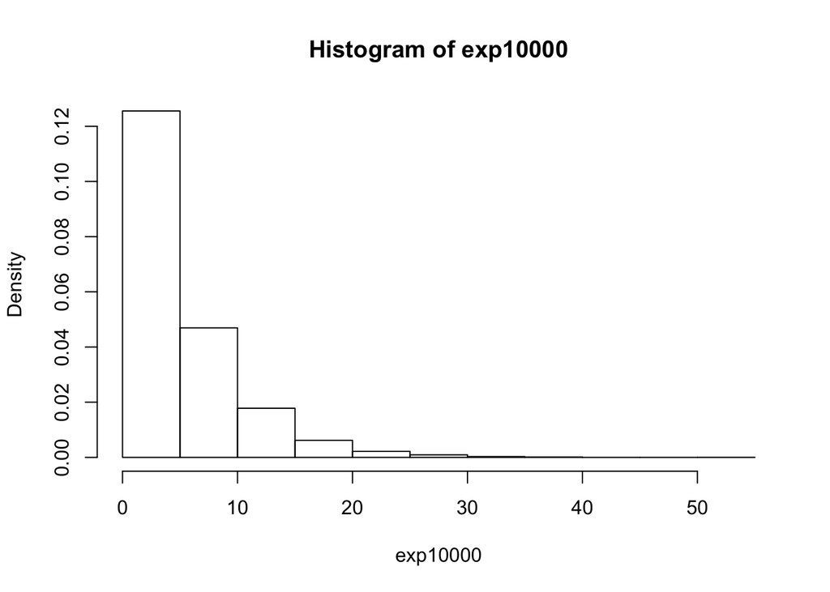